# MUSA 508 Lab 3 - Lab Exercise

Rui Jiang

September, 2022

# Introduction

After uploading the data, we will do some geoprocessing using SF, and then you will undertake two data visualization exercises.

This .rmd document will then be the basis for you to “knit” your own Markdown HTML document, which is the presentation format for your homeworks due next week.

# Setup

## Load Themes

Create your mapping and plotting themes.

Add to these and create color palettes if you please!

```r
# Load functions

root.dir = "https://raw.githubusercontent.com/urbanSpatial/Public-Policy-Analytics-Landing/master/DATA/"
source("https://raw.githubusercontent.com/urbanSpatial/Public-Policy-Analytics-Landing/master/functions.r")
```

## Load Census API Key

```r
census_api_key("YOUR API KEY", overwrite = TRUE, install= TRUE)
```

```
## [1] "YOUR API KEY"
```

# Load the data

First step is to clone the repo for the lab 3 data (using github desktop) so we have the data.

You can clone the repo using the “file” tab in Github Desktop and using [this URL:](https://github.com/urbanSpatial/Public-Policy-Analytics-Landing)

[Learn more about embedding links and using bold and italics in markdown here](https://rmarkdown.rstudio.com/authoring_basics.html)

## Read in the data

Notice that this code is a bit different from that in the text. The filepath in the github data is a bit different. Yours will look different too depending on where the data were cloned to (probably your GitHub folder).

```r
lancCounty <- st_read("https://raw.githubusercontent.com/urbanSpatial/Public-Policy-Analytics-Landing/master/DATA/Chapter2/LancasterCountyBoundary.geojson") %>%
  st_transform('ESRI:102728')
uga <- st_read("https://raw.githubusercontent.com/urbanSpatial/Public-Policy-Analytics-Landing/master/DATA/Chapter2/Urban_Growth_Boundary.geojson") %>%
  st_transform('ESRI:102728')
studyAreaTowns <- st_read("https://raw.githubusercontent.com/urbanSpatial/Public-Policy-Analytics-Landing/master/DATA/Chapter2/StudyAreaTowns.geojson") %>%
  st_transform('ESRI:102728')
buildings <- st_read("https://raw.githubusercontent.com/urbanSpatial/Public-Policy-Analytics-Landing/master/DATA/Chapter2/LancasterCountyBuildings.geojson") %>% st_transform('ESRI:102728')
greenSpace <- st_read("https://raw.githubusercontent.com/urbanSpatial/Public-Policy-Analytics-Landing/master/DATA/Chapter2/LancasterGreenSpace.geojson") %>% st_transform('ESRI:102728')
```

## Exploring our spatial data

Let’s explore these data sets by using commands like `glimpse()`

What do you find? What kind of data are these?

Make some simple ggplots with `geom_sf` by mapping the municipalities, the Lancaster County Boundary and the UGA and put them in a chunk right here:

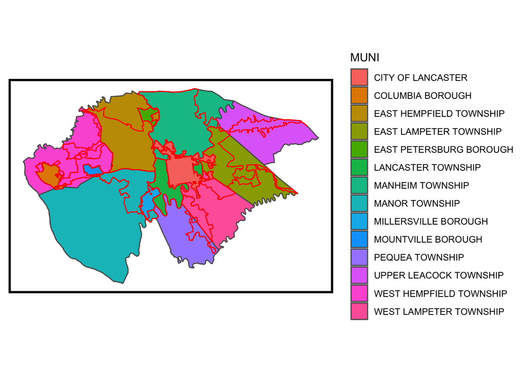

```r
ggplot()+
  geom_sf(data = studyAreaTowns, aes(fill = MUNI))+ #use MUNI to give color
  geom_sf(data = uga, fill = "transparent", color = "red")+
  mapTheme()
```

# Geoprocessing

We are going to do some meat-and-potatoes vector GIS - union and buffer.

## Union

Merging all the shapes. The use of `st_buffer(1)` is to add a little bit of room (here it is 1ft) to consolidates small inconsistencies in the outline of each UGA polygon. These occur when digitizing polygons is not perfectly done; and rarely is it perfect!

```r
uga_union <-
  st_union(uga) %>%
  st_buffer(1) %>%
  st_sf()
```

## Outside and inside buffers

We create our `outsideBuffer`, our `insideBuffer` and then we `rbind` the buffers together.

What is `rbind` doing? What are the conditions that allow it to work?

```r
outsideBuffer <-
  st_buffer(uga_union, 660) %>%
  st_difference(uga_union) %>%
  mutate(Legend = "Outside")


insideBuffer <-
  st_buffer(uga_union, dist = -660) %>%
  st_difference(uga_union, .) %>%
  mutate(Legend = "Inside")

bothBuffers <- rbind(insideBuffer, outsideBuffer)
```

# Map the buffers

Here is a basic plot of the buggers that we have created.

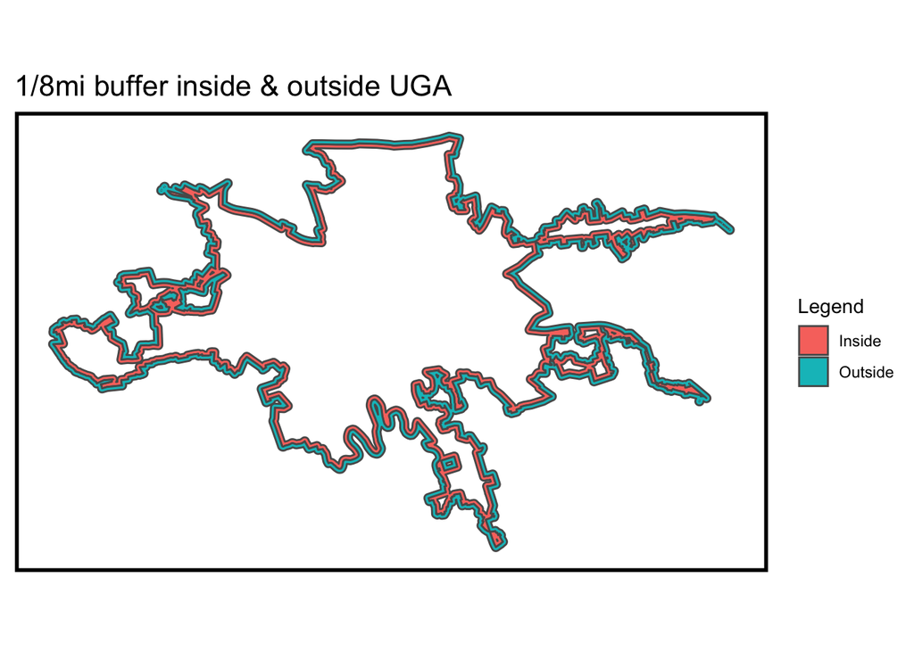

```r
ggplot() +
  geom_sf(data = bothBuffers, aes(fill = Legend)) +
  scale_fill_manual(values = c("#F8766D", "#00BFC4")) +
  labs(title = "1/8mi buffer inside & outside UGA") +
  mapTheme()
```

# Join the Town info to the buffers

Here `st_make_valid()` is used to fix inconsistencies in polygon geometry. Try running the code without `st_make_valid` and you will see an error about invalid geometry due to self-intersecting polygons. Note: You will see the warning message of `attribute variables are assumed to be spatially constant ...`. It is an informative warning and you will see it often working with {sf}, but you can ignore it.

```r
buffersAndTowns <-
  st_intersection(st_make_valid(studyAreaTowns),
                  bothBuffers) %>%
  filter(MUNI != "MOUNTVILLE BOROUGH")
```

```
## Warning: attribute variables are assumed to be spatially constant throughout all
## geometries
```

# Mapping Challenge 1

Find a way to map the inside and outside buffers nicely that distinguishes them from each other AND shows the municipalities they belong to. Try manipulating the colors (remember our palettes, and the `viridis` package? remember `scale_fill_manual`). Add geographic context. Add legends and titles and subtitles.

Consider how you might label objects in your map using

`geom_sf_text(data = studyAreaTowns, aes(label = MUNI), size = 3)`

Think about ways to manipulate the `studyAreaTowns` data inside that text geom to make it more legible.

Put all this code into a markdown chunk that runs correctly and allows this markdown to `knit`. Then see if you can manipulate the chunk options so that there aren’t annoying warnings and other messages you don’t want showing up in an assignment.